# Downstream Analysis Notebook - Tabula muris version

Tabula Muris P8_15 trachea

Dídac Jiménez

23-03-2023

## Purpose

The purpose of this notebook is to analyze the already preprocessed data provided by Tabula Muris as `.robj` and obtain:

- The t-SNE cluster image
- A table with the top 10 diferentially expressed genes of each cluster

We can then use these results to compare them with those obtained with the scRNA-seq data that we preprocessed.

## Preparation and setup

### Set parameters

Indicate the path to the `extid2description.csv` file. It was obtained through Biomart and is available in the github.

```r
extid2descriptionpath<-"~/Work/Code/scRNAseq-Preprocessing-benchmark/Refs/extid2description.csv"
```

Indicate the path to the `.robj`. These are available in the Tabula Muris website and provide the counts matrix as well as other data in an expressionSet-like object from the `Seurat` package. However, the objects are from an outdated version of the library (V2) so we need to update it to ours.

```r
load("~/Work/Datasets/Mouse/Robjects/droplet_Trachea_seurat_tiss.Robj")
seurat.obj <- UpdateSeuratObject(tiss)
```

```
## Updating from v2.X to v3.X
```

```
## Validating object structure
```

```
## Updating object slots
```

```
## Ensuring keys are in the proper structure
```

```
## Ensuring feature names don't have underscores or pipes
```

```
## Object representation is consistent with the most current Seurat version
```

```r
rm(tiss)
```

Other parameters to be used:

```r
# nFeature_threshold <- c(500, 25000) # subset. Minimum and maximum number of features detected in a cell to be kept
# nCount_threshold <- c(1000, 500000)  # subset. Minimum and maximum number of molecules detected in a cell to be kept
dispersion.cutoff <- c(0.1, Inf) # FindVariableFeatures: Threshold of log dispersion
mean.cutoff <- c(0.5, Inf) # FindVariableFeatures: Threshold of log mean expression
n.pcs <- 6 # Number of principal components used for clustering. This hsould actually be chosen through the elbow plot
resolution <- 0.1 # Resolution used in linear cluster
perplexity <- 15 # Perplexity for t-SNE
```

## Quality Control

### Data exploration

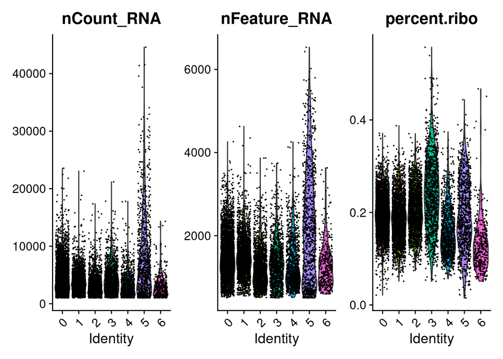

```r
VlnPlot(seurat.obj, features = c("nCount_RNA", "nFeature_RNA","percent.ribo"), ncol = 3)
```

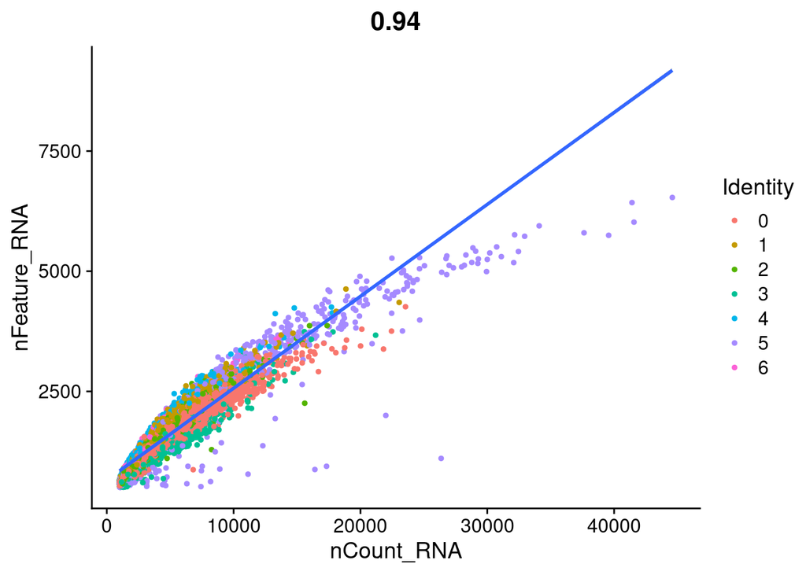

```r
FeatureScatter(seurat.obj, feature1 = "nCount_RNA", feature2 = "nFeature_RNA")+geom_smooth(method='lm')
```

### Filtering

We filter the cells by setting a limit on: *Mitochondrial percentage: An upper limit, high values may indicate a broken nucleus, thus a compromised cell. For this notebook this is currently a work in progress.* Number of molecules: An upper limit, very high values may indicate the droplet contained two cells *Number of features: A lower limit, droplets with too few features may only contein environmental RNA

These filters depend on each dataset and should be changed on each execution.

```r
seurat.obj.filtered <- subset(x = seurat.obj, subset=nFeature_RNA > 500 & nFeature_RNA < 3000 &
                                nCount_RNA > 1000 & nCount_RNA < 10000)
```

We make the violin plots again to check the filtering:

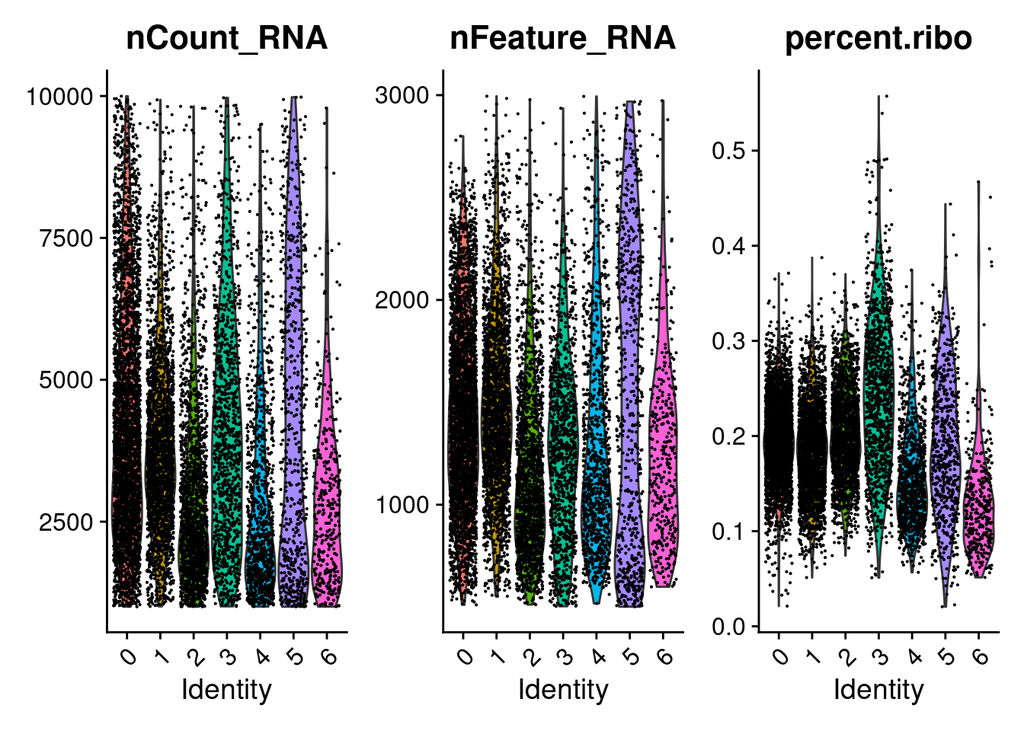

```r
VlnPlot(seurat.obj.filtered, features = c("nCount_RNA", "nFeature_RNA", "percent.ribo"), ncol = 3)
```

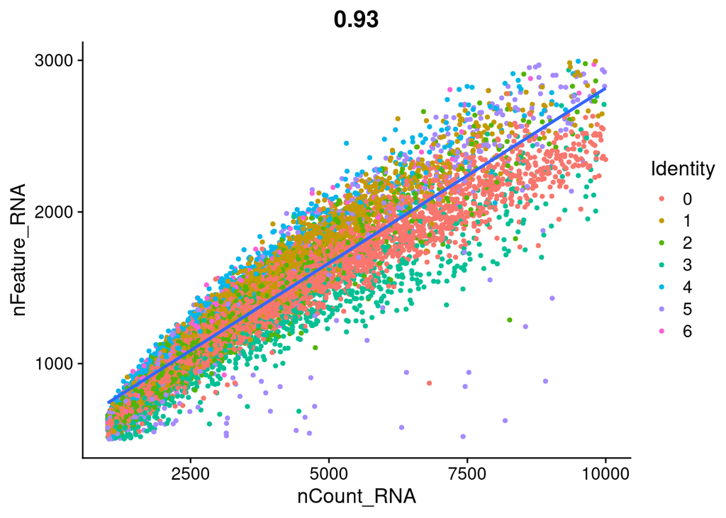

```r
FeatureScatter(seurat.obj.filtered, feature1 = "nCount_RNA", feature2 = "nFeature_RNA")+geom_smooth(method='lm')
```

## Notmalization and scaling

### Normalization

Normalize the values so we can make comparisons across cells. Each value is divided by the total expression in its cell, multiplied by a scale factor and then log transformed.

$$N_{ij}=log(1+M\frac{A_{ij}}{\sum_{j'}A_{ij'}}) \\
M=10⁴$$

```r
seurat.obj.filtered<-NormalizeData(object=seurat.obj.filtered)
```

### Highly variable features

We do this to focus our analysis on the genes that differentiate our cells. We select the genes with high standarized log dispersion. The log dispersion $d$ of a gene $i$ with mean and variance standarized expresion $v_i,m_i$ is simply:

$$d_i = log(v_i/m_i)$$

```r
seurat.obj.filtered <- FindVariableFeatures(object = seurat.obj.filtered,  mean.cutoff = mean.cutoff,
  dispersion.cutoff = dispersion.cutoff)
```

### Scale data

We run `ScaleData()` to shift the expression of each gene, so that the mean expression across cells is 0 and scales the expression of each gene, so that the variance across cells is 1. This step gives equal weight in downstream analyses, so that highly-expressed genes do not dominate and is a required step prior to dimensional reduction techniques.

$$X{ij}=(N_{ij}-\mu_i)/\sigma_i$$

```r
gene_names <- rownames(seurat.obj.filtered)
seurat.obj.filtered <- ScaleData(seurat.obj.filtered, vars.to.regress = c("nCount_RNA",  "percent.ribo"))
```

## Dimension reduction

### Principal Component Analysis

We run the analysis with `RunPCA()`.

```r
seurat.obj.filtered <- RunPCA(seurat.obj.filtered, features =VariableFeatures(seurat.obj.filtered), ndims.print = 1)
seurat.obj.filtered <- ProjectDim(seurat.obj.filtered)
```

```
## PC_ 1
## Positive:  Sparc, Wif1, Mgp, Mia1, Cytl1, Chad, Col11a1, 3110079O15Rik, Acan, Col9a2
##     Ucma, Fn1, Hapln1, 1500015O10Rik, Col27a1, Col2a1, Col8a1, Col9a3, Lect1, Sox9
## Negative:  Tyrobp, Fcer1g, Ctss, Cd52, Laptm5, Tmsb4x, Cd74, H2-Aa, Ucp2, H2-Ab1
##     H2-Eb1, Cd83, Sfpi1, Cd53, Plek, Lyz2, Ccl9, Lcp1, Alox5ap, Coro1a
## PC_ 2
## Positive:  Fcer1g, Tyrobp, Ctss, Cst3, H2-Aa, Sfpi1, H2-DMb1, Cd83, H2-Ab1, H2-Eb1
##     Ccl9, Laptm5, Plek, Cd52, Alox5ap, Lilrb4, Cd74, Cybb, Ms4a6c, Gm11428
## Negative:  Krt19, Krt8, Krt15, Aqp3, Tacstd2, Krt7, Wfdc2, Cyp2f2, Sult1d1, Krt18
##     Gpx2, Gsta4, Lypd2, Spint2, Epcam, S100a14, Ces1d, Gsto1, Krt5, Perp
## PC_ 3
## Positive:  Fxyd3, Cytl1, Chad, 3110079O15Rik, Mia1, Ucma, Col9a2, Col11a1, Acan, Col9a3
##     Col2a1, Lgals3, Lect1, Hapln1, Sdc4, Col9a1, Cbr2, Sfn, Mfi2, Wif1
## Negative:  Cd34, Serping1, Dpt, Igfbp4, Ifitm3, Col1a1, Mfap5, Col3a1, Clec3b, Rarres2
##     Vim, Ppap2b, Igfbp6, Fbln1, Nrp1, Col15a1, Aqp1, Fbln2, Lgals1, Serpinf1
## PC_ 4
## Positive:  Emcn, Flt1, Pecam1, Egfl7, Cdh5, Esam, Ptprb, Podxl, Plvap, Eltd1
##     Ctla2a, Mmrn2, Gpr116, Apold1, Cd93, Kdr, Tie1, Myct1, Rasip1, Slc9a3r2
## Negative:  Gsn, Col1a1, Col3a1, Lgals1, Dpt, Serpinf1, Mfap5, Serping1, Col1a2, Clec3b
##     Dcn, Nbl1, Fbln1, Rarres2, Igfbp6, Pcolce, Mmp2, Igfbp4, C3, Ecm1
## PC_ 5
## Positive:  Iyd, Tpo, Prlr, Dio1, Ager, Kcnh3, Folr1, Cdh16, Fxyd4, Asgr1
##     Gjb1, Scg5, Slc4a5, Bex4, Tg, Prom2, Chchd10, Clic3, Derl3, Kcnj16
## Negative:  Krt15, Sult1d1, Cyp2f2, Cbr2, Aqp3, Krt5, Gsto1, Scgb3a2, Ifitm1, Gsta4
##     S100a6, Oit1, Aqp4, Upk1b, Fmo3, Selenbp1, Krt4, Sox2, Cyp4b1, Sox21
```

We make an elbow plot. We want to keep enough PC’s to capture most of the variation

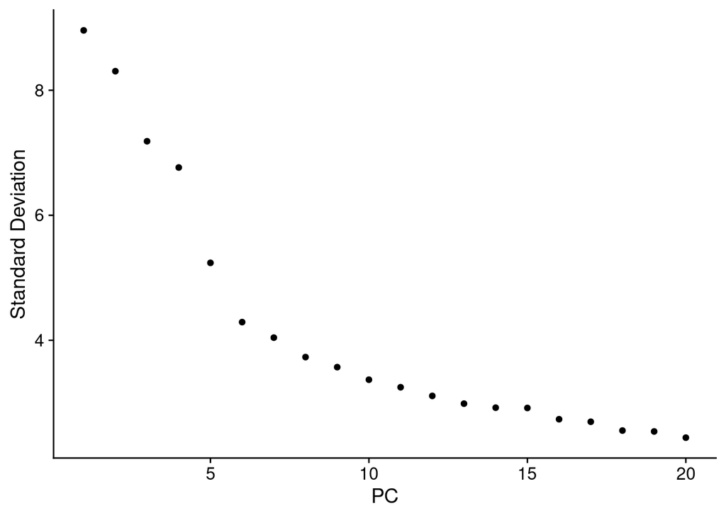

```r
ElbowPlot(seurat.obj.filtered)
```

From this plot we should choose the number of principal components to use in clustering.

### Clustering

Here we specify how many PCA’s to use and the resolutions for the cluster. We then plot the cells by their two first principal components.

```r
seurat.obj.filtered <- FindNeighbors(seurat.obj.filtered,dims = 1:n.pcs)
seurat.obj.filtered <- FindClusters(seurat.obj.filtered, resolution = resolution)
```

```
## Modularity Optimizer version 1.3.0 by Ludo Waltman and Nees Jan van Eck
##
## Number of nodes: 11269
## Number of edges: 341587
##
## Running Louvain algorithm...
## Maximum modularity in 10 random starts: 0.9658
## Number of communities: 8
## Elapsed time: 1 seconds
```

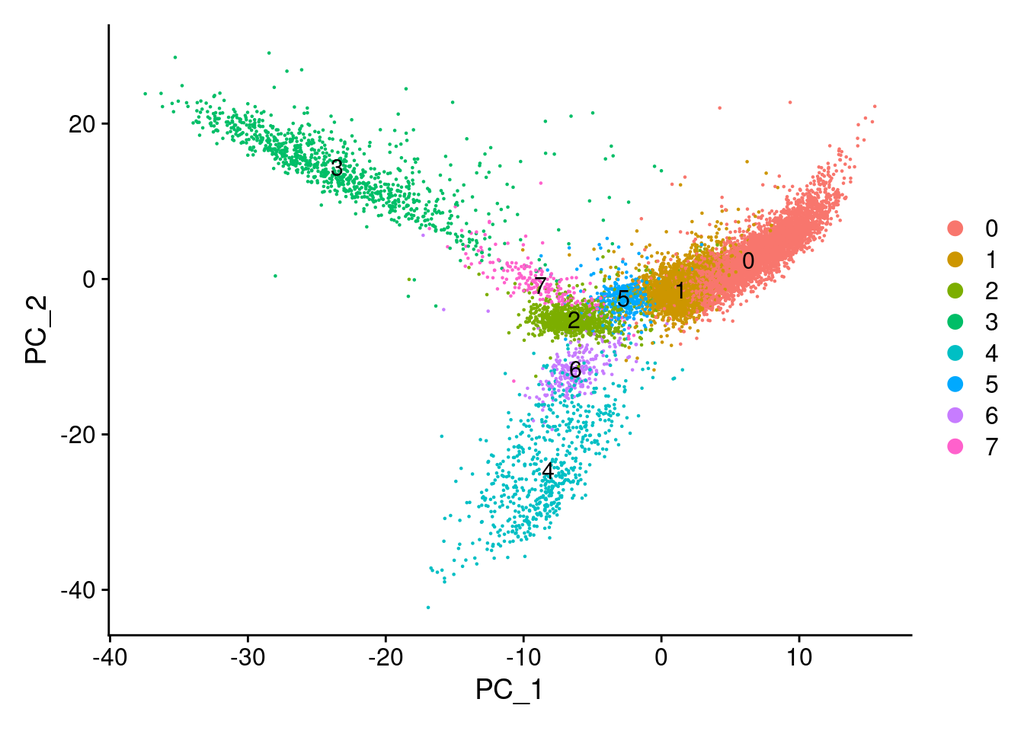

```r
DimPlot(seurat.obj.filtered , dims = c(1,2), reduction = "pca", label = TRUE)
```

More useful, as it is the type of cluster graphic is the *t-distributed stochastic neighbor embedding*, which is a dimensionality reduction method that discriminates clusters really well. First, the probability proportional to similarity is calculated for each pair. For data point $x_{j}$ to data point $x_{i}$ this is the conditional probability, $p_{j|i}}$, that $x_{i}$ would pick $x_{j}$ as its neighbor if neighbors were picked in proportion to their probability density under a student t centered at $x_{i}$. Then a distribution in the lower space is computed iteratively (through gradient descent) to minimize the Kullback–Leibler divergence between it and the full dimensional distribution.

For our application, we will use Seurat’s `RunTSNE`. It does not work directly on the genes as dimensions as t-SNE struggles with too many dimensions. It uses the principal components computed above, sins PC are good at separating signal from noise. We need to choose a parameter named perplexity that roughly sets how much impact closer points have over points further apart.

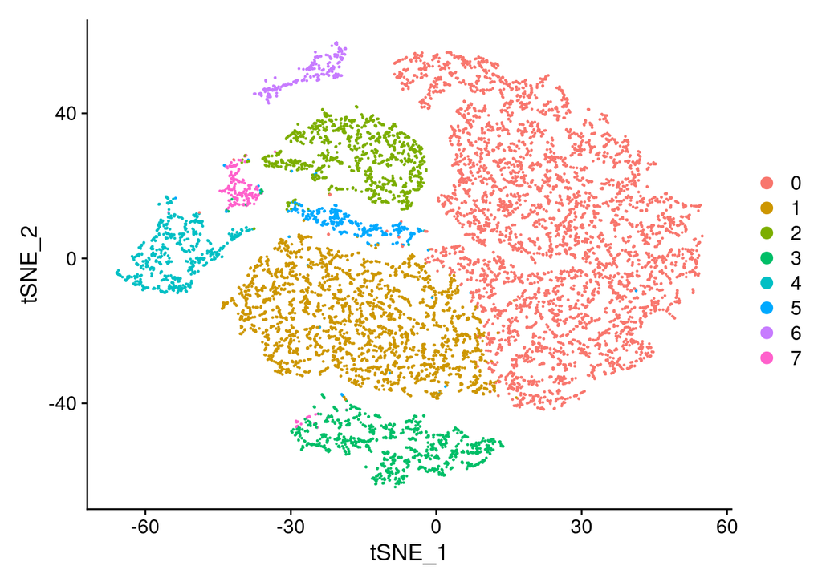

```r
seurat.obj.filtered <- RunTSNE(seurat.obj.filtered, dims.use = 1:n.pcs, seed.use = 10, perplexity = perplexity, dim.embed = 2)
TSNEPlot(seurat.obj.filtered)
```

We obtain the differentially expressed genes for each cluster with the function `FindAllMarkers`. This provides a table with the gene id, the cluster in which it is differentially expressed, both p-values (normal and adjusted, and only those under `return.thresh`) and the log fold change (more on it below).

```r
markers <- FindAllMarkers(object = seurat.obj.filtered, only.pos = TRUE, min.pct = 0.25, return.thresh = 0.01)
rownames(markers) <- c()
```

$$log2FC=log_2(\frac{Average\ expression\
in\ set\ 1}{Average\ expression\ in\ set\ 2})$$

Where set 1 would be a given cluster and set 2 the whole set. However, the actual calculation in the function is:

```
data.1 <- apply(X = data.use[genes.use, cells.1, drop = F], MARGIN = 1, FUN = function(x) log(x = mean(x = expm1(x = x)) + pseudocount.use))
data.2 <- apply(X = data.use[genes.use, cells.2, drop = F], MARGIN = 1, FUN = function(x) log(x = mean(x = expm1(x = x)) + pseudocount.use))
total.diff <- (data.1 - data.2)
```

Which has 2 caveats:

```r
externalid2description<-read.csv(extid2descriptionpath)
anotated_table <- data.frame()
for(i in unique(markers$cluster)){
  markers %>%
    dplyr::select(gene, p_val_adj, avg_log2FC, cluster) %>%
    filter(cluster ==i) %>%
    top_n(5, avg_log2FC) %>%
    left_join(externalid2description, by = "gene") %>%
    dplyr::select(gene, p_val_adj, avg_log2FC, cluster, description) ->
    cluster
    anotated_table <- rbind(anotated_table, cluster)
}

knitr::kable(anotated_table)
```

| gene | p_val_adj | avg_log2FC | cluster | description |
| --- | --- | --- | --- | --- |
| Cytl1 | 0 | 5.270520 | 0 | cytokine-like 1 [Source:MGI Symbol;Acc:MGI:2684993] |
| 3110079O15Rik | 0 | 4.404369 | 0 | NA |
| Col2a1 | 0 | 4.367216 | 0 | collagen, type II, alpha 1 [Source:MGI Symbol;Acc:MGI:88452] |
| Ucma | 0 | 3.956629 | 0 | upper zone of growth plate and cartilage matrix associated [Source:MGI Symbol;Acc:MGI:1915777] |
| Chad | 0 | 3.737950 | 0 | chondroadherin [Source:MGI Symbol;Acc:MGI:1096866] |
| Dpt | 0 | 3.598319 | 1 | dermatopontin [Source:MGI Symbol;Acc:MGI:1928392] |
| Col3a1 | 0 | 3.513453 | 1 | collagen, type III, alpha 1 [Source:MGI Symbol;Acc:MGI:88453] |
| Clec3b | 0 | 3.461688 | 1 | C-type lectin domain family 3, member b [Source:MGI Symbol;Acc:MGI:104540] |
| Igfbp6 | 0 | 3.281195 | 1 | insulin-like growth factor binding protein 6 [Source:MGI Symbol;Acc:MGI:96441] |
| Dcn | 0 | 3.271455 | 1 | decorin [Source:MGI Symbol;Acc:MGI:94872] |
| Fabp4 | 0 | 4.248115 | 2 | fatty acid binding protein 4, adipocyte [Source:MGI Symbol;Acc:MGI:88038] |
| Plvap | 0 | 4.044037 | 2 | plasmalemma vesicle associated protein [Source:MGI Symbol;Acc:MGI:1890497] |
| Emcn | 0 | 3.909631 | 2 | endomucin [Source:MGI Symbol;Acc:MGI:1891716] |
| Ly6c1 | 0 | 3.355802 | 2 | lymphocyte antigen 6 complex, locus C1 [Source:MGI Symbol;Acc:MGI:96882] |
| Ctla2a | 0 | 3.353192 | 2 | cytotoxic T lymphocyte-associated protein 2 alpha [Source:MGI Symbol;Acc:MGI:88554] |
| Cd74 | 0 | 7.002050 | 3 | CD74 antigen (invariant polypeptide of major histocompatibility complex, class II antigen-associated) [Source:MGI Symbol;Acc:MGI:96534] |
| H2-Aa | 0 | 6.138614 | 3 | histocompatibility 2, class II antigen A, alpha [Source:MGI Symbol;Acc:MGI:95895] |
| H2-Ab1 | 0 | 6.001115 | 3 | histocompatibility 2, class II antigen A, beta 1 [Source:MGI Symbol;Acc:MGI:103070] |
| H2-Eb1 | 0 | 5.894655 | 3 | histocompatibility 2, class II antigen E beta [Source:MGI Symbol;Acc:MGI:95901] |
| Tyrobp | 0 | 4.509728 | 3 | TYRO protein tyrosine kinase binding protein [Source:MGI Symbol;Acc:MGI:1277211] |
| Wfdc2 | 0 | 5.215964 | 4 | WAP four-disulfide core domain 2 [Source:MGI Symbol;Acc:MGI:1914951] |
| Scgb3a2 | 0 | 5.182904 | 4 | secretoglobin, family 3A, member 2 [Source:MGI Symbol;Acc:MGI:2153470] |
| Gsto1 | 0 | 5.077015 | 4 | glutathione S-transferase omega 1 [Source:MGI Symbol;Acc:MGI:1342273] |
| Cyp2f2 | 0 | 5.062069 | 4 | cytochrome P450, family 2, subfamily f, polypeptide 2 [Source:MGI Symbol;Acc:MGI:88608] |
| Scgb1a1 | 0 | 4.860075 | 4 | secretoglobin, family 1A, member 1 [Source:MGI Symbol;Acc:MGI:98919] |
| Tagln | 0 | 4.351890 | 5 | transgelin [Source:MGI Symbol;Acc:MGI:106012] |
| Myl9 | 0 | 3.872272 | 5 | myosin, light polypeptide 9, regulatory [Source:MGI Symbol;Acc:MGI:2138915] |
| Acta2 | 0 | 5.095052 | 5 | actin alpha 2, smooth muscle, aorta [Source:MGI Symbol;Acc:MGI:87909] |
| Il6 | 0 | 3.682910 | 5 | interleukin 6 [Source:MGI Symbol;Acc:MGI:96559] |
| Mbp | 0 | 3.738725 | 5 | myelin basic protein [Source:MGI Symbol;Acc:MGI:96925] |
| Chchd10 | 0 | 4.583210 | 6 | coiled-coil-helix-coiled-coil-helix domain containing 10 [Source:MGI Symbol;Acc:MGI:2143558] |
| Ager | 0 | 3.754999 | 6 | advanced glycosylation end product-specific receptor [Source:MGI Symbol;Acc:MGI:893592] |
| Iyd | 0 | 3.607984 | 6 | iodotyrosine deiodinase [Source:MGI Symbol;Acc:MGI:1917587] |
| Dusp2 | 0 | 3.299701 | 6 | dual specificity phosphatase 2 [Source:MGI Symbol;Acc:MGI:101911] |
| Tg | 0 | 7.360829 | 6 | thyroglobulin [Source:MGI Symbol;Acc:MGI:98733] |
| Cxcr6 | 0 | 3.394511 | 7 | chemokine (C-X-C motif) receptor 6 [Source:MGI Symbol;Acc:MGI:1934582] |
| Cd3g | 0 | 3.286206 | 7 | CD3 antigen, gamma polypeptide [Source:MGI Symbol;Acc:MGI:88333] |
| Icos | 0 | 3.236016 | 7 | inducible T cell co-stimulator [Source:MGI Symbol;Acc:MGI:1858745] |
| Ltb | 0 | 3.103098 | 7 | lymphotoxin B [Source:MGI Symbol;Acc:MGI:104796] |
| Crem | 0 | 3.074907 | 7 | cAMP responsive element modulator [Source:MGI Symbol;Acc:MGI:88495] |

Lastly, we compute the same table but with more markers and we save it to a file. We will use it to compare this table, obtained from already preprocessed scRNA-Seq data, to the same table obtained with data preprocessed by the pipelines.

```r
anotated_table <- data.frame()
for(i in unique(markers$cluster)){
  markers %>%
    dplyr::select(gene, p_val_adj, avg_log2FC, cluster) %>%
    filter(cluster ==i) %>%
    top_n(10, avg_log2FC) %>%
    left_join(externalid2description, by = "gene") %>%
    dplyr::select(gene, p_val_adj, avg_log2FC, cluster, description) ->
    cluster
    anotated_table <- rbind(anotated_table, cluster)
}

write_csv(anotated_table, "~/Work/Code/scRNAseq-Preprocessing-benchmark/Refs/anotated_table_P8_15.csv")
```